# Home assignement: Stochastic models

This tutorial illustrates the manipulation of stochastic models and signals.

## Part 1: Processing and spectral analysis of Local Field Potentials

Local Field Potentials (LFPs) designate the "low" frequency part of the electrical potential in the extracellular medium of the brain, typically below 200Hz. It reflects many network processes, and is assumed to be generated, to a large extended, by post-synaptic currents entering the neurons.

Let us load some exemplary data recoded from the macaque hippocampus that you can dowload from https://owncloud.tuebingen.mpg.de/index.php/s/REc82bzpCetG27T (update the dataPath variable below before loading).

```python
# load local field potential
from scipy import io
import numpy as np
import matplotlib.pyplot as plt
import matplotlib.axes as axes
from scipy.signal import welch,butter,lfilter, filtfilt
from scipy.linalg import toeplitz
```

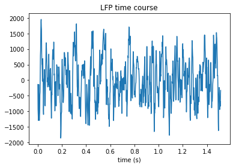

```python
lfpdat = io.loadmat("./LFPdat.mat")

# Define LFP time series
LFP = lfpdat['LFP'][:,0]
# Define sampling period dt (sampling frequency is 660Hz)
dt = lfpdat['dt'][:,0]
fs = 660;
t = np.arange(LFP.shape[0])*dt

# we plot only the begining of the recording
plt.plot(t[0:1000],LFP[0:1000])
plt.title('LFP time course')
plt.xlabel('time (s)')
plt.show()
```

We want to estimate the Power Spectral Density of the LFP signal. We use the scipy.signal.welch function for this purpose. **Please refer to the spectral analysis tutorial on Ilias (tutorial 2) for the use of this function.**

**Important: plot all periodograms with a physical frequency axis (Hz)**

**Question 1:**

- (a) The "nperseg" controls the width (number of points of the segments used by the algorithm to compute a single DFT (with the FFT algorithm). We want to get a frequency resolution of approximately 1Hz, how should we choose (as an order of magnitude) the "nperseg" parameter? Plot the welch periodogram of the LFP signal. What are the dominate which frequencies (in Hz) in this signal.

Frequency resolution $\Delta f$ is the spacing between data points in frequency. The frequency resolution the bandwidth divided by the spectral lines which is also same with Sampling Frequency divided by Block Size (nperseg).

$\Delta f = \frac{Bandwidth}{Spectral Lines} = \frac{Sampling Frequency}{Block Size}$

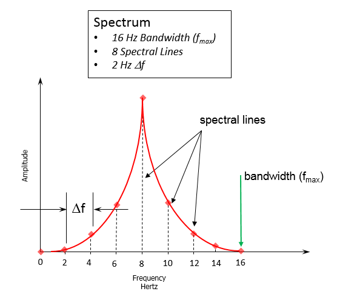

For our case we have $Sampling Frequency = 660Hz\\$ and we would like to have $\Delta f = 1Hz$ So:

$Block Size = \frac{Sampling Frequency}{\Delta f}=660$

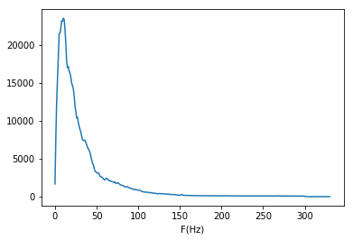

```python
nperseg_val = 660;
[freq,pwy] = welch(LFP,axis=0,nperseg=nperseg_val, fs=660);
plt.plot(freq,pwy);
plt.xlabel('F(Hz)')
plt.show();
```

```python
np.argmax(pwy)
```

```
10
```

As we can see the dominant frequency is around 10Hz.

- (b) The time resoved power in the so called gamma band of the LFP has been reported to reflect the amount of recurrent activity in the network, and is relates to the BOLD signal measured in fMRI. Perform the following operations to extract this time resolved amplitude:
  - filter the LFP in the [60,120Hz] band to obtain signal $g$ (use scipy.signal.filtfilt to apply a zero phase filter),
  - take the square of $g$, $g^2$,
  - low pass filter $g^2$ below $60Hz$ to get $g_{pow}$ the time resolved gamma power. For each signal (LFP,$g$ ,$g^2$,$g_{pow}$), estimate the PSD with the Welch periodogram and plot it.

```python
lowcut = 60;
highcut = 120;
nyq = 0.5 * fs;
low = lowcut / nyq;
high = highcut / nyq;
order = 3;

b, a = butter(order, [low, high], btype='band');

g = filtfilt(b, a, LFP);
g_sqr = g**2;

b, a = butter(order, low, btype='low');
g_pow = filtfilt(b, a, g_sqr);
```

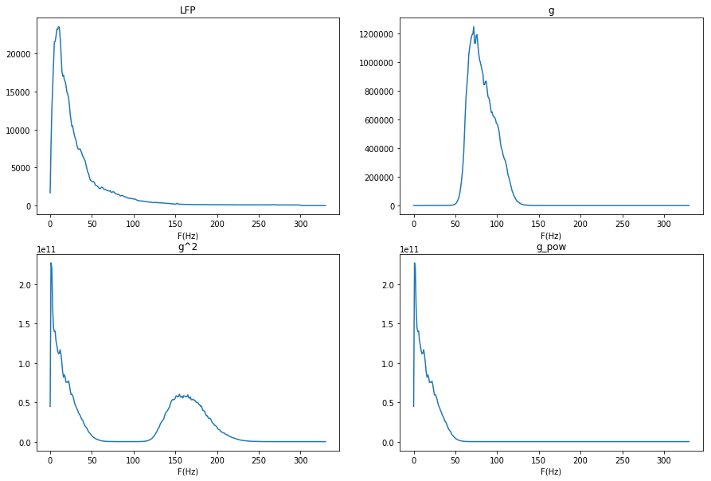

```python
[freq_g, pwy_g] = welch(g,axis=0,nperseg=nperseg_val);
[freq_g_sqr, pwy_g_sqr] = welch(g_sqr,axis=0,nperseg=nperseg_val);
[freq_g_pow, pwy_g_pow] = welch(g_pow,axis=0,nperseg=nperseg_val);

plt.figure(figsize=(15, 10));

plt.subplot(2,2,1);
plt.plot(freq, pwy);
plt.title('LFP');
plt.xlabel('F(Hz)');

freq_g = freq_g*660;
plt.subplot(2,2,2);
plt.plot(freq_g, pwy_g);
plt.title('g');
plt.xlabel('F(Hz)');

freq_g_sqr = freq_g_sqr*660;
plt.subplot(2,2,3);
plt.plot(freq_g_sqr, pwy_g_sqr);
plt.title('g^2');
plt.xlabel('F(Hz)');

freq_g_pow = freq_g_pow*660;
plt.subplot(2,2,4);
plt.plot(freq_g_pow, pwy_g_pow);
plt.title('g_pow');
plt.xlabel('F(Hz)');

plt.show();
```

- (c) Given that the periodogram reflects (to some extent, see lecture) the expected squared modulus of the Fourier transform of signal realisations, justify qualitatively the shape taken the successive PSDs (why particular frequencies appear or are preserved/removed)

However, after we squared g, In $g^2$, we can see plot from 0-60Hz and 120-240Hz. To explaint this, I will use the fourier transform of $\cos (w_0 t)$.

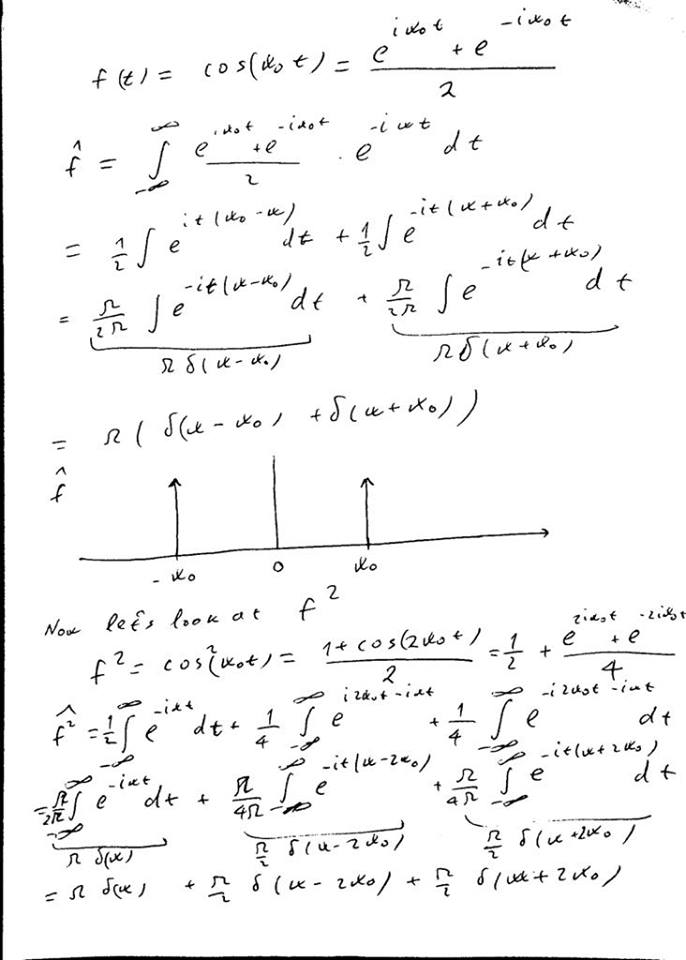

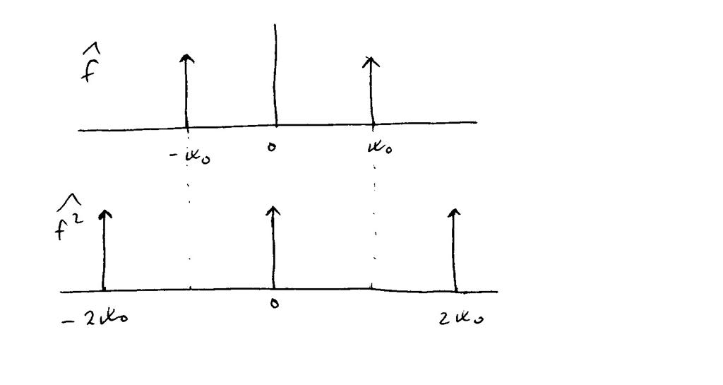

As we can see, when we squared the function, we have a changed frequency in fourier transform. We had frequency at $w_0$ but squaring the function has changed the frequency at 0 and $2w_0$. Intuitively, I would say the same thing happened when we squared g and in $g^2$, we can see a PSD in 0-60Hz and 120-240 Hz ranges.

In $g_{pow}$, we low bandpass filtered by 60Hz so that we removed the 120-240Hz signals from $g^2$.

- (d) Based on the above periodogram of $g_{pow}$, justify that downsampling it by taking every 5th point is reasonable (hint: reason as if the downsampled signal corresponds to directly sampling the corresponding continuous signal, compute the new sampling frequency and the Nyquist frequency to justify).

- (e) Plot the square root of $g_{pow}$ and check if follows the enveloppe of $g$ correctly.

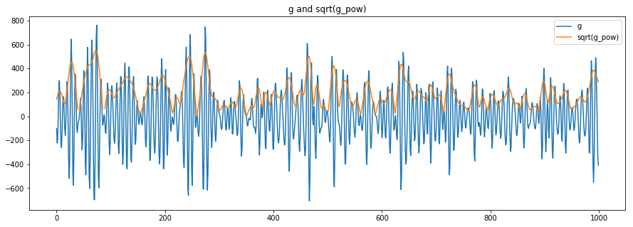

```python
g_pow_sqr_root = np.sqrt(g_pow);

plt.figure(figsize=(15, 5));
plt.plot(g[5000:6000], label = 'g');
plt.plot(g_pow_sqr_root[5000:6000], label = 'sqrt(g_pow)');
plt.title('g and sqrt(g_pow)');
plt.legend()
```

As we can see that square root of g_pow follows the enveloppe of g.

- (e) Downsample $g_{pow}$ as explained, to obtain $g_d$ and compute an estimate of its PSD, with the same frequency resolution (which window size should be taken now in the welch function? By comparing the PSD with the orginal one, is the downsampling well behaved? Justify qualitatively why the chosen frequency was appropriate.

Since we are sampling with every 5th point, we have $f_d = f/5 = 660Hz/5 = 132Hz$. So to get our $1Hz$ frequency resolution, we need $nperseg = 132$.

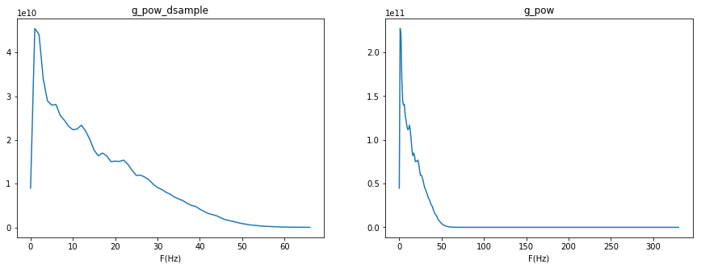

```python
g_pow_dsample = g_pow[0::5];
new_sampling_freq = fs/5;
nyquist_frequency = new_sampling_freq/2;

[freq_g_pow_dsample, pwy_g_pow_dsample] = welch(g_pow_dsample,axis=0,nperseg=nperseg_val/5);

plt.figure(figsize=(15, 5));

freq_g_pow_dsample = freq_g_pow_dsample*(nperseg_val/5);
plt.subplot(1,2,1);
plt.plot(freq_g_pow_dsample, pwy_g_pow_dsample);
plt.title('g_pow_dsample');
plt.xlabel('F(Hz)');

plt.subplot(1,2,2);
plt.plot(freq_g_pow, pwy_g_pow);
plt.title('g_pow');
plt.xlabel('F(Hz)');

plt.show();
```

## Part 2: Estimation of auto and crosscorrelation functions

Given a single realisation of an observed time series (i.e. on single "trial"), to estimate the quantities $\gamma_{XX}$ and $\gamma_{XY}$ defined in the lecture (for $X$,$Y$ jointly stationary processes), we essentially replace the expectation $\mathbb{E}$ in the formulas by an average over time $\frac{1}{T}\sum_{t=1}^T$. This time of estimate is implemented correctly in the *statsmodels* library, with *statsmodels.tsa.statstools.acovf* and *ccovf* (note the naming covariance differs from the term we used in the lecture, but they designate the same object).

Install the library and check the code of the functions available at https://www.statsmodels.org/stable/tsa.html, note they call the *numpy.correlate* routine. Note statsmodels has a conda library available for installation if you use anaconda (see https://anaconda.org/anaconda/statsmodels).

```python
from statsmodels.tsa.stattools import acovf,ccovf
```

**Question 2:**

- (a) Explain what does the "unbiased" option implemented by the acovf and ccovf routines.

If we have $X$ random variables and we want to estimate $E(x_n x_{n-d})$ where $n \in {0...N-1}$, we can average for each data:

$E(x_n x_{n-d}) = \frac{1}{N-d} \sum^{N-1}_{n=d}x_n x_{n-d}$

This is unbiased estimate and it will converge to true value as you use more data for large $N$. However, when $d$ is closer to the N, estimation will be less acurate as there is not enough data.

As for Biased estimate:

$E(x_n x_{n-d}) = \frac{1}{N} \sum^{N-1}_{n=d}x_n x_{n-d}$

This is biased estimate and it will not converge to true value because it is always dividing by $1/N$ even though there is less number of values.

- (b) From reading the code (and the numpy routine "correlate" used in it), the routines return a one-sided function (set of lags start from zero). Given a vector for sample $x$ and $y$, should we use ccovf(x,y) or ccovf(y,x) to estimate $\gamma_{XY}$ as defined in the lecture **for the positive values of lag $\tau$**? Justify.

In lecture, we have equation for $\gamma_{XY}$ as:

$\gamma_{XY}(\tau) = \mathbf{E}[\bar{X}[0]\cdot Y[\tau]$

If we look at it more graphically for time lag $\tau = 0$:

| $X_0$ | $X_1$ | ... | $X_N$ |
| --- | --- | --- | --- |
| $Y_0$ | $Y_1$ | ... | $Y_N$ |

If we look at it more graphically for positive time lag $\tau = T$:

| ... | ... | $X_0$ | $X_1$ | ... | $X_{N-T}$ | ... | $X_N$ |
| --- | --- | --- | --- | --- | --- | --- | --- |
| $Y_0$ | ... | $Y_T$ | $Y_{T+1}$ | ... | $Y_N$ |  |  |

If we look at it more graphically for negative time lag $\tau = -T$:

| $X_0$ | $X_1$ | ... | $X_{T}$ | ... | $X_N$ | ... | ... |
| --- | --- | --- | --- | --- | --- | --- | --- |
| ... | ... | ... | $Y_0$ | ... | $Y_{N-T}$ | ... | $Y_N$ |

However, in ccovf(x, y), we wouldn't get positive time lag of X and Y. In the source code, they multiply $Y_{N-1}$ with $X_0$ until $Y_0$ with $X_{N-1}$ and we would get the right side of the multiplication.

In other words from here:

| $X_0$ | $X_1$ | ... | $X_N$ |
| --- | --- | --- | --- |
| $Y_0$ | $Y_1$ | ... | $Y_N$ |

Shift the Y to right and until this:

| $X_0$ | $X_1$ | ... | $X_{N}$ | ... | ... |
| --- | --- | --- | --- | --- | --- |
| ... | ... | ... | $Y_0$ | ... | $Y_{N}$ |

And All this is negtave time lag for $\gamma_{XY}$. So to get positive time lag for $\gamma_{XY}(\tau)$ we have to use ccovf(y, x);

- (c) How can we use the acovf and ccovf routines to compute the auto- and cross-correlations to get the functions on an axis spanning both positive and negative lags? Write the code to do that and justify with symmetries shown in the lecture.

Since acovf use np.correlate(a, b, 'full')[n-1:] and cut half of the correlation using [n-1:], we will have a correlation starting from 0 to N-1. To get the negative lag -(N - 1), we can just mirror the positive half.

However, we would get only positve time lag from ccovf(x, y) function. To get the negative time lag:

$\gamma_{XY}(-\tau) = E(X[0]Y[-\tau]) = E(X[\tau]Y[0]) = E(Y[0]X[\tau]) => \gamma_{YX}(\tau) $

from here we can see that $\gamma_{YX}(\tau)$ with positive $\tau$ is actually equal to the $\gamma_{XY}(-\tau)$ with negative time lag.

ccovf(y, x) also use np.correlate(a, b, 'full')[n-1:] and to get the other half we can get the ccovf(x, y) and flip to get the negative lag of the ccovf.

```python
def acov(x, unbiased_val):
    acovf_pos = acovf(x, unbiased = unbiased_val);
    acovf_full = np.concatenate((np.flip(acovf_pos[1:len(x)]), acovf_pos), axis=None);
    return acovf_full;

def ccov(x, y, unbiased_val):
    ccovf_pos = ccovf(y, x, unbiased = unbiased_val);

    ccovf_neg = ccovf(x, y, unbiased = unbiased_val);
    ccovf_neg = np.flip(ccovf_neg[1:len(ccovf_neg)]);

    ccovf_full = np.concatenate((ccovf_neg, ccovf_pos), axis=None);
    return ccovf_full;
```

- (d) Generate a white noise realization $\eta$ with 1000 i.i.d. Gaussian samples. Using the option "ubiased=False", estimate the autocorrelation function for both positive and negative lags (-999 to 999) and plot it. Compare the obtained estimate with the theoretical value.

```python
N = 1000;
lags = np.arange(-999, 1000);
mu, sigma = 0, 1;

nu = np.random.normal(mu, sigma, N);
```

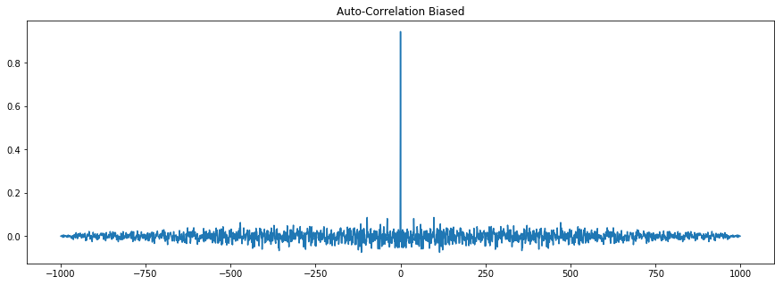

```python
acov_nu = acov(nu, False);
plt.figure(figsize=(15, 5));
plt.plot(lags, acov_nu, linestyle='-');
plt.title('Auto-Correlation Biased');
```

As wee can see when the time lag is zero, we would get the highest correlation because X would be highest correlated with itself at zero lag.

- (e) Repeat the analysis with the option "unbiased=True". What changes in the estimate and why?

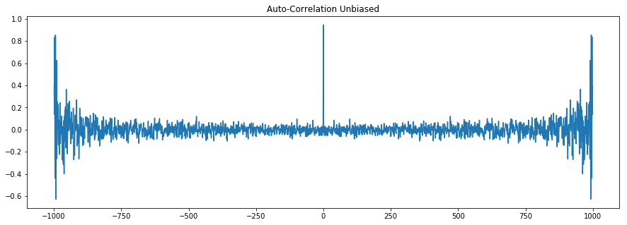

```python
acov_nu = acov(nu, True);
plt.figure(figsize=(15, 5));
plt.plot(lags, acov_nu, linestyle='-');
plt.title('Auto-Correlation Unbiased');
```

Since we are using unbiased, the more lag is closer to the N, we get less accurate estimation.

- (f) Compute a 10 samples-lagged version $\xi$ of the above noise sequence $\eta$ and adjust the length of the original sequence $\eta$ so that both signals have the same length. Estimate the cross-correlation function $\gamma_{\eta\xi}$ (using "unbiased=False") between the two series, for both positive and negative lags, and plot it. Does the estimate correspond to the theory, justify?

```python
epsilon = nu[10:]
nu_adjusted = nu[:len(nu)-10];
```

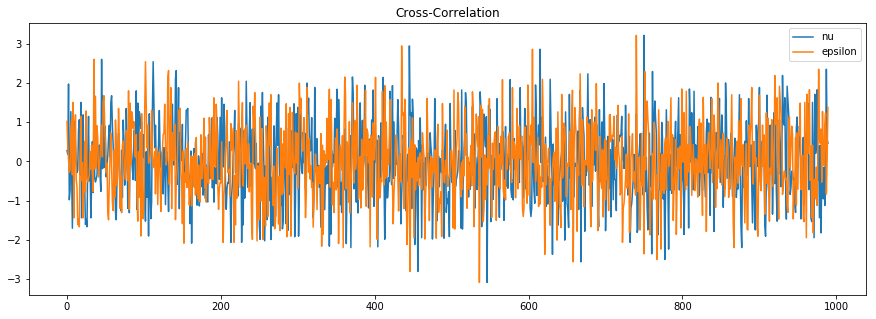

```python
plt.figure(figsize=(15, 5));
plt.plot(nu_adjusted, label = 'nu');
plt.plot(epsilon, label = 'epsilon');
plt.title('Cross-Correlation');
plt.legend();
plt.show();
```

We can see that epsilon is lagged behind nu by 10 sample. We should expect negative $\tau = -10$ delay in cross-correlation.

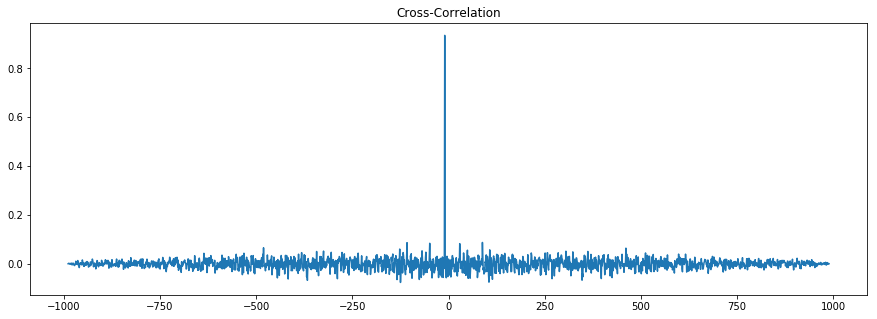

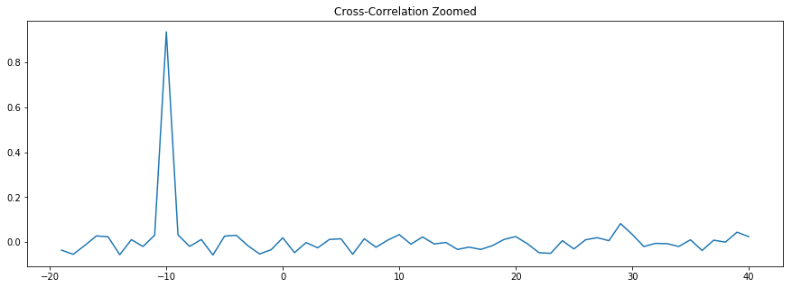

```python
lags_cc = np.arange(-989, 990);
ccovf_ = ccov(nu_adjusted, epsilon, False);

plt.figure(figsize=(15, 5));
plt.plot(lags_cc, ccovf_, linestyle='-');
plt.title('Cross-Correlation');
plt.show();
plt.figure(figsize=(15, 5));
plt.plot(lags_cc[970:1030], ccovf_[970:1030], linestyle='-');
plt.title('Cross-Correlation Zoomed');
plt.show();
```

Since we shifted the 2nd signal with 10 samples, we would expect to have highest correlation at time lag -10 and we see that from the plot.

## Part 3: A LTI model of neurovascular coupling

Functional Magnetic Resonance Imaging measures the Blood Oxygen Level Dependent (BOLD) signal related to the concentration of oxyhemoglobin in the brain tissue and is used to assess functional brain activity.

While the link between neural activity and BOLD is complex, involving several non-linear phenomena, and still elusive, the fMRI community has since long used a linear time invariant system to model this relation. The impulse response of this model is called the Hemodynamic Response Function (HRF), and can be used to investiagte properties of neural activity based on fMRI measurements.

### Reference HRF

We first define a reference HRF in continuous time, similar to those used in popular software such as SPM (https://www.fil.ion.ucl.ac.uk/spm/).

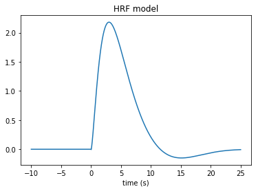

```python
import scipy.stats as stats

def hrf(t):
    pars = [2.5, 2.02, 14.5, 0.247]
    resp = pars[2]*stats.gamma.pdf(t,pars[0],scale = pars[1])-pars[3]*np.exp(-(t-25/2)**2/(12/1.8)**2)
    resp[t<0] = 0
    return resp

t= np.arange(-10,25,.01)

plt.plot(t,hrf(t))
plt.title('HRF model')
plt.xlabel('time (s)')
plt.show()
```

**Question 3:**

- Use the *hrf* function to sample the impulse response at the sampling frequency of the above downsampled signal $g_d$ (approximately 132Hz). Note the impulse response is causal (values before $t=0$ are zero). We can thus sample the hrf on an interval [0,25s]. Use this sampled HRF, that we will call $h$ to compute an estimate $y$ of the BOLD signal in response to a rectangular signal $x_T(t)=\begin{cases}1,\,\text{if}\, t\in [0,T]\\0 ,\text{otherwise}\end{cases}$ idealized signals $x$ representing neural activity, for $T=.1s,1s$ and $10s$. Comment (briefly) on the similarity between the shape of the HRF and the shape of the response $y$ for different values of $T$ (use properties of convolution seen in the lectures).

```python
def x_t(t, T):
    x = np.zeros(len(t));
    x[t <= T] = 1;
    return x;
```

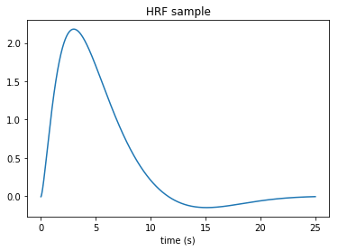

```python
t= np.arange(0,25,1/132);

hrf_sample = hrf(t);

T = [0.1, 1, 10, 15, 20, 25];

plt.plot(t, hrf_sample);
plt.title('HRF sample')
plt.xlabel('time (s)')
plt.show()
```

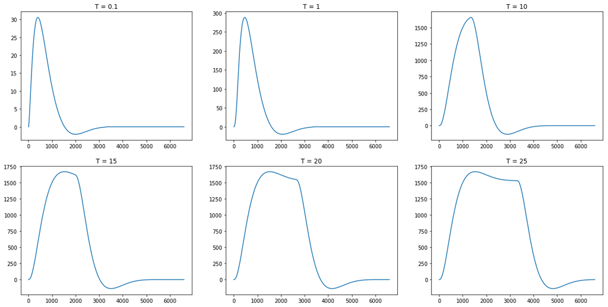

```python
plt.figure(figsize=(20, 10));

for i in range(len(T)):
    rec_signal_x = x_t(t, T[i]);
    y = np.convolve(hrf_sample, rec_signal_x);

    plt.subplot(2,3,i + 1);
    plt.plot(y);
    plt.title('T = {}'.format(T[i]));
```

### LFP based model

As an approximation for the neural activity, i.e. the input of the HRF-based model, we can take the time resolved gamma band power $g_d$ computed above. You can check these papers for further details: https://www.ncbi.nlm.nih.gov/pubmed/11449264 https://www.jneurosci.org/content/32/4/1395

Let us reload the previously computed gamma power signal available at https://owncloud.tuebingen.mpg.de/index.php/s/3HN9jAmGW7miZ4t, sampled at approximately 132Hz (1/dt). We will also remove the mean and normalize the amplitude for simplicity. We will now call this normalized input signal $x$.

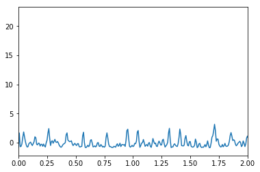

```python
gpow = np.load('.\gammaPower.npz')
x = gpow['x']
x = x -np.mean(x)
x = x/np.std(x)
dt = gpow['dt']
t = np.arange(len(x))*dt
plt.plot(t,x)
plt.xlim([0,2]);
```

**Question 4**

- (a) Generate a simulated BOLD signal $y$ by convolving the gamma power signal $x$ by the sampled HRF $h$, and then adding a Gaussian white noise of variance 1.

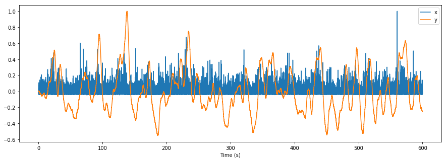

```python
y = np.convolve(hrf_sample, x, 'full')[0:len(t)];
gaussian_noise = np.random.normal(0, 1, len(y));
y = y + gaussian_noise;

plt.figure(figsize=(15, 5));
plt.plot(t, x/(np.max(x)), label='x');
plt.plot(t, y[0:len(x)]/(np.max(y)), label='y');
plt.xlabel('Time (s)')
plt.legend();
```

We can see a little right shifted y compared to x.

- (b) Compute and plot the autocovariance functions of $x$ and $y$, and the cross-covariance $\gamma_{xy}$ between them for a lag axis of [-40,40] **seconds** (normalize their amplitude to their respective maximum to allow comparison on the same graph).

```python
lags = np.arange(-40, 40+1/132, 1/132);
```

```python
acov_x = acov(x, False);
acov_y = acov(y, False);
ccov_xy = ccov(x, y, False);
```

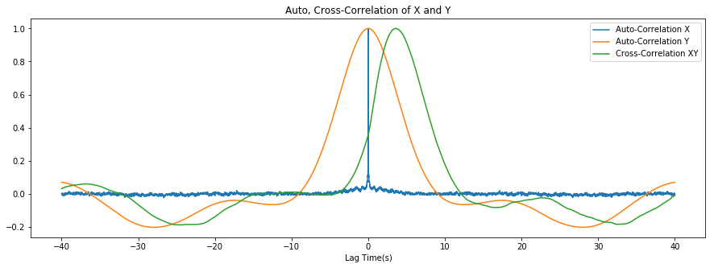

```python
start = int(((len(acov_x) - 1) / 2) - 5280);
end = int(((len(acov_x) - 1) / 2) + 5281);

plt.figure(figsize=(15, 5));
plt.plot(lags, acov_x[start:end]/(np.max(acov_x[start:end])), linestyle='-', label = 'Auto-Correlation X');

start = int(((len(acov_y) - 1) / 2) - 5280);
end = int(((len(acov_y) - 1) / 2) + 5281);
plt.plot(lags, acov_y[start:end]/(np.max(acov_y[start:end])), linestyle='-', label = 'Auto-Correlation Y');

start = int(((len(ccov_xy) - 1) / 2) - 5280);
end = int(((len(ccov_xy) - 1) / 2) + 5281);

plt.plot(lags, ccov_xy[start:end]/(np.max(ccov_xy[start:end])), linestyle='-', label = 'Cross-Correlation XY');

plt.title('Auto, Cross-Correlation of X and Y');
plt.xlabel('Lag Time(s)');
plt.legend();
plt.show();
```

From the plot, we can see positive Lag tau.

- (c) We aim at estimating the filter $h$ based only on its input $x$ and output $y$. Use the auto- and cross-correlation function estimates to build the matrix $A$ and vector $d$ seen in lecture 8 (identification of a FIR model, **check the updated slides on Ilias**). To construct $A$, you can check and use the *scipy.linalg.toeplitz* routine. For simplicity, choose the size of the maximum delay $p$ that corresponds to the true $h$.

```python
p = 3300;

start_ind = int((len(acov_x) - 1)/2 + 1);
end_ind = int((len(acov_x) - 1)/2 + 1 + p);
A = toeplitz(acov_x[start_ind:end_ind]);

start_ind = int((len(ccov_xy) - 1)/2 + 1);
end_ind = int((len(ccov_xy) - 1)/2 + 1 + p);
d = ccov_xy[start_ind:end_ind].reshape(1, len(ccov_xy[start_ind:end_ind]));
```

- (d) Invert the system $Ab=d$ in order to get an estimate $\hat{h}$ of $h$. Is the fit qualitatively good?

```python
b = np.matmul(d, np.linalg.inv(A));
```

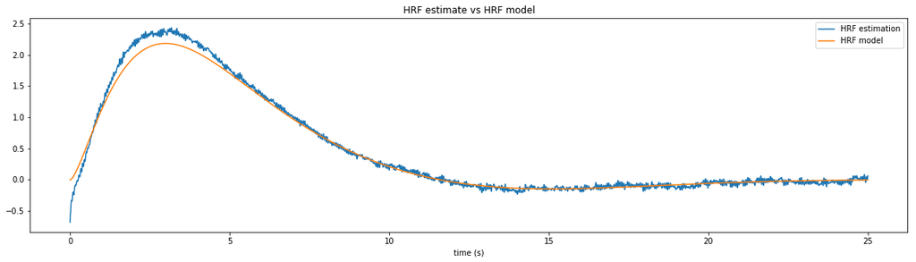

```python
t= np.arange(0,25,1/132);

plt.figure(figsize=(20, 5));

# plt.subplot(1,2,1);
plt.plot(t, b[0], label = 'HRF estimation');
plt.plot(t, hrf_sample , label = 'HRF model');
plt.title('HRF estimate vs HRF model')
plt.xlabel('time (s)')
plt.legend()

# plt.subplot(1,2,2);
# plt.plot(t, hrf_sample);
# plt.title('HRF model')
# plt.xlabel('time (s)')
```

As we can see from above plot, the estimation is very close to the model.

- (e) The original estimate was based on the full time course of the signals (600s). Quantify how varies the mean square error of the estimate of $h$ when we estimate auto- and cross-correlation functions only from on initial segment of data of $30$, $100$, and $200s$. Compare the performance of using biased ("unbiased=False") and unbiased estimates in these cases.

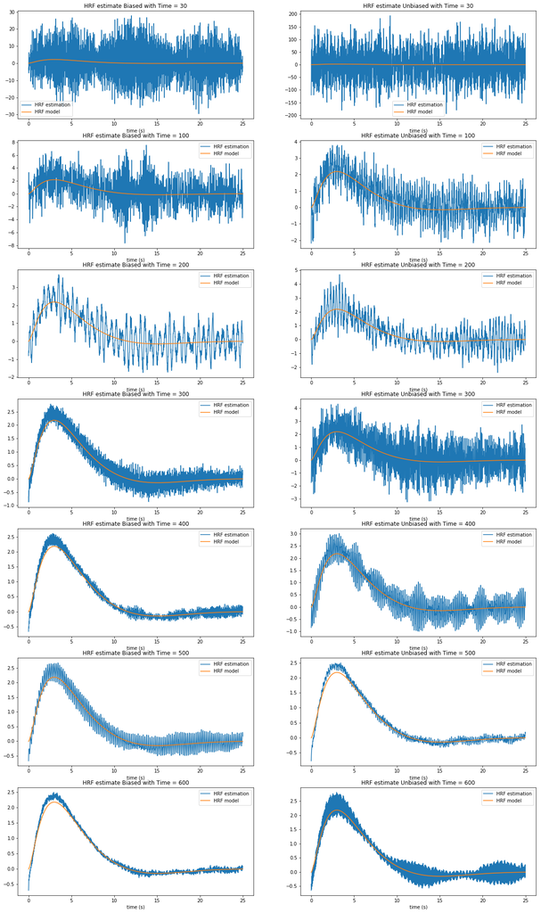

```python
segment_data = np.array([30, 100, 200, 300, 400, 500, 600]);
nrmse = np.zeros((len(segment_data), 2));

plt.figure(figsize=(20, 35));

for i in range(len(segment_data)):

    t = np.arange(0, segment_data[i], 1/132);
    y = np.convolve(hrf_sample, x[0:len(t)])[0:len(t)];
    gaussian_noise = np.random.normal(mu, sigma, len(y));
    y = y + gaussian_noise;

    acov_x = acov(x[0:len(t)], False);
    ccov_xy = ccov(x[0:len(t)], y, False);

    start_ind = int((len(acov_x) - 1)/2 + 1);
    end_ind = int((len(acov_x) - 1)/2 + 1 + p);
    A = toeplitz(acov_x[start_ind:end_ind]);

    start_ind = int((len(ccov_xy) - 1)/2 + 1);
    end_ind = int((len(ccov_xy) - 1)/2 + 1 + p);
    d = ccov_xy[start_ind:end_ind].reshape(1, len(ccov_xy[start_ind:end_ind]));
    b = np.matmul(d, np.linalg.inv(A));

    nrmse[i][0] = np.sqrt(np.sum((b - hrf_sample)**2)/len(b))/(np.max(hrf_sample) - np.min(hrf_sample));

    t_1 = np.arange(0, 25,1/132);

    plt.subplot(len(segment_data), 2, i*2 + 1);
    plt.plot(t_1, b[0], label = 'HRF estimation');
    plt.plot(t_1, hrf_sample , label = 'HRF model');
    plt.title('HRF estimate Biased with Time = {}'.format(segment_data[i]));
    plt.xlabel('time (s)');
    plt.legend()

    acov_x = acov(x[0:len(t)], True);
    ccov_xy = ccov(x[0:len(t)], y, True);

    start_ind = int((len(acov_x) - 1)/2 + 1);
    end_ind = int((len(acov_x) - 1)/2 + 1 + p);
    A = toeplitz(acov_x[start_ind:end_ind]);

    start_ind = int((len(ccov_xy) - 1)/2 + 1);
    end_ind = int((len(ccov_xy) - 1)/2 + 1 + p);
    d = ccov_xy[start_ind:end_ind].reshape(1, len(ccov_xy[start_ind:end_ind]));
    b = np.matmul(d, np.linalg.inv(A));

    nrmse[i][1] = np.sqrt(np.sum((b - hrf_sample)**2)/len(b))/(np.max(hrf_sample) - np.min(hrf_sample));

    plt.subplot(len(segment_data), 2, i*2 + 2);
    plt.plot(t_1, b[0], label = 'HRF estimation');
    plt.plot(t_1, hrf_sample , label = 'HRF model');
    plt.title('HRF estimate Unbiased with Time = {}'.format(segment_data[i]));
    plt.xlabel('time (s)');
    plt.legend()

plt.show()
```

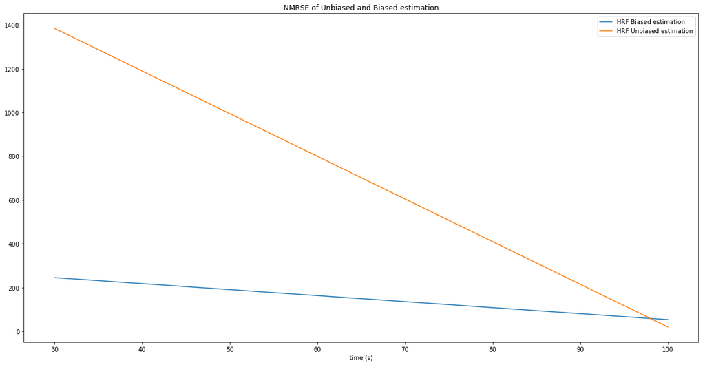

```python
plt.figure(figsize=(20, 10));
plt.plot(segment_data[0:2], np.transpose(nrmse)[0][0:2], label='HRF Biased estimation');
plt.plot(segment_data[0:2], np.transpose(nrmse)[1][0:2], label='HRF Unbiased estimation');
plt.title('NMRSE of Unbiased and Biased estimation'.format(segment_data[i]));
plt.xlabel('time (s)');
plt.legend()
```

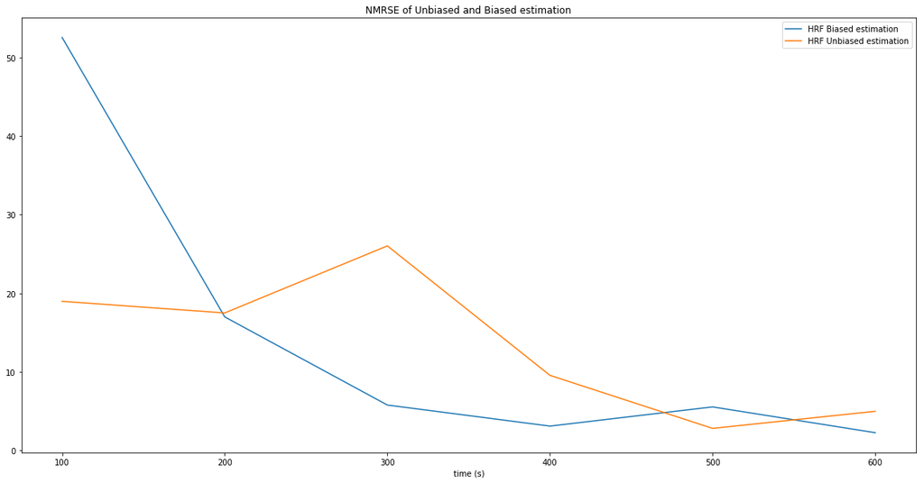

```python
plt.figure(figsize=(20, 10));
plt.plot(segment_data[1:], np.transpose(nrmse)[0][1:], label='HRF Biased estimation');
plt.plot(segment_data[1:], np.transpose(nrmse)[1][1:], label='HRF Unbiased estimation');
plt.title('NMRSE of Unbiased and Biased estimation'.format(segment_data[i]));
plt.xlabel('time (s)');
plt.legend()
```